# Risk Factor Analysis

## Outcome Variable

**Outcome Variable:** whz

## Predictor Variables

**Intervention Variable:** mbmi

**Adjustment Set:**

unadjusted

## Stratifying Variables

The analysis was stratified on these variable(s):

- agecat
- studyid
- country

## Data Summary

| agecat | studyid | country | mbmi | n_cell | n |
| --- | --- | --- | --- | --- | --- |
| Birth | ki0047075b-MAL-ED | BANGLADESH | Normal weight | 205 | 233 |
| Birth | ki0047075b-MAL-ED | BANGLADESH | Underweight | 28 | 233 |
| Birth | ki0047075b-MAL-ED | BRAZIL | Normal weight | 167 | 176 |
| Birth | ki0047075b-MAL-ED | BRAZIL | Underweight | 9 | 176 |
| Birth | ki0047075b-MAL-ED | INDIA | Normal weight | 157 | 195 |
| Birth | ki0047075b-MAL-ED | INDIA | Underweight | 38 | 195 |
| Birth | ki0047075b-MAL-ED | NEPAL | Normal weight | 167 | 167 |
| Birth | ki0047075b-MAL-ED | NEPAL | Underweight | 0 | 167 |
| Birth | ki0047075b-MAL-ED | PERU | Normal weight | 264 | 269 |
| Birth | ki0047075b-MAL-ED | PERU | Underweight | 5 | 269 |
| Birth | ki0047075b-MAL-ED | SOUTH AFRICA | Normal weight | 221 | 226 |
| Birth | ki0047075b-MAL-ED | SOUTH AFRICA | Underweight | 5 | 226 |
| Birth | ki0047075b-MAL-ED | TANZANIA, UNITED REPUBLIC OF | Normal weight | 109 | 116 |
| Birth | ki0047075b-MAL-ED | TANZANIA, UNITED REPUBLIC OF | Underweight | 7 | 116 |
| Birth | ki1000304b-SAS-CompFeed | INDIA | Normal weight | 77 | 110 |
| Birth | ki1000304b-SAS-CompFeed | INDIA | Underweight | 33 | 110 |
| Birth | ki1017093-NIH-Birth | BANGLADESH | Normal weight | 23 | 28 |
| Birth | ki1017093-NIH-Birth | BANGLADESH | Underweight | 5 | 28 |
| Birth | ki1017093c-NIH-Crypto | BANGLADESH | Normal weight | 17 | 23 |
| Birth | ki1017093c-NIH-Crypto | BANGLADESH | Underweight | 6 | 23 |
| Birth | ki1119695-PROBIT | BELARUS | Normal weight | 13143 | 13664 |
| Birth | ki1119695-PROBIT | BELARUS | Underweight | 521 | 13664 |
| Birth | ki1126311-ZVITAMBO | ZIMBABWE | Normal weight | 8573 | 9029 |
| Birth | ki1126311-ZVITAMBO | ZIMBABWE | Underweight | 456 | 9029 |
| 6 months | ki0047075b-MAL-ED | BANGLADESH | Normal weight | 209 | 241 |
| 6 months | ki0047075b-MAL-ED | BANGLADESH | Underweight | 32 | 241 |
| 6 months | ki0047075b-MAL-ED | BRAZIL | Normal weight | 199 | 208 |
| 6 months | ki0047075b-MAL-ED | BRAZIL | Underweight | 9 | 208 |
| 6 months | ki0047075b-MAL-ED | INDIA | Normal weight | 186 | 235 |
| 6 months | ki0047075b-MAL-ED | INDIA | Underweight | 49 | 235 |

[output cut: 52 more lines]

The following strata were considered:

- agecat: 24 months, studyid: ki0047075b-MAL-ED, country: BANGLADESH
- agecat: 24 months, studyid: ki0047075b-MAL-ED, country: BRAZIL
- agecat: 24 months, studyid: ki0047075b-MAL-ED, country: INDIA
- agecat: 24 months, studyid: ki0047075b-MAL-ED, country: NEPAL
- agecat: 24 months, studyid: ki0047075b-MAL-ED, country: PERU
- agecat: 24 months, studyid: ki0047075b-MAL-ED, country: SOUTH AFRICA
- agecat: 24 months, studyid: ki0047075b-MAL-ED, country: TANZANIA, UNITED REPUBLIC OF
- agecat: 24 months, studyid: ki1017093-NIH-Birth, country: BANGLADESH
- agecat: 24 months, studyid: ki1017093b-PROVIDE, country: BANGLADESH
- agecat: 24 months, studyid: ki1017093c-NIH-Crypto, country: BANGLADESH
- agecat: 24 months, studyid: ki1066203-TanzaniaChild2, country: TANZANIA, UNITED REPUBLIC OF
- agecat: 24 months, studyid: ki1119695-PROBIT, country: BELARUS
- agecat: 24 months, studyid: ki1126311-ZVITAMBO, country: ZIMBABWE
- agecat: 24 months, studyid: ki1148112-LCNI-5, country: MALAWI
- agecat: 6 months, studyid: ki0047075b-MAL-ED, country: BANGLADESH
- agecat: 6 months, studyid: ki0047075b-MAL-ED, country: BRAZIL
- agecat: 6 months, studyid: ki0047075b-MAL-ED, country: INDIA
- agecat: 6 months, studyid: ki0047075b-MAL-ED, country: NEPAL
- agecat: 6 months, studyid: ki0047075b-MAL-ED, country: PERU
- agecat: 6 months, studyid: ki0047075b-MAL-ED, country: SOUTH AFRICA
- agecat: 6 months, studyid: ki0047075b-MAL-ED, country: TANZANIA, UNITED REPUBLIC OF
- agecat: 6 months, studyid: ki1000304b-SAS-CompFeed, country: INDIA
- agecat: 6 months, studyid: ki1017093-NIH-Birth, country: BANGLADESH
- agecat: 6 months, studyid: ki1017093b-PROVIDE, country: BANGLADESH
- agecat: 6 months, studyid: ki1017093c-NIH-Crypto, country: BANGLADESH
- agecat: 6 months, studyid: ki1066203-TanzaniaChild2, country: TANZANIA, UNITED REPUBLIC OF
- agecat: 6 months, studyid: ki1119695-PROBIT, country: BELARUS
- agecat: 6 months, studyid: ki1126311-ZVITAMBO, country: ZIMBABWE
- agecat: 6 months, studyid: ki1148112-LCNI-5, country: MALAWI
- agecat: Birth, studyid: ki0047075b-MAL-ED, country: BANGLADESH
- agecat: Birth, studyid: ki0047075b-MAL-ED, country: BRAZIL
- agecat: Birth, studyid: ki0047075b-MAL-ED, country: INDIA
- agecat: Birth, studyid: ki0047075b-MAL-ED, country: NEPAL
- agecat: Birth, studyid: ki0047075b-MAL-ED, country: PERU
- agecat: Birth, studyid: ki0047075b-MAL-ED, country: SOUTH AFRICA
- agecat: Birth, studyid: ki0047075b-MAL-ED, country: TANZANIA, UNITED REPUBLIC OF
- agecat: Birth, studyid: ki1000304b-SAS-CompFeed, country: INDIA
- agecat: Birth, studyid: ki1017093-NIH-Birth, country: BANGLADESH
- agecat: Birth, studyid: ki1017093c-NIH-Crypto, country: BANGLADESH
- agecat: Birth, studyid: ki1119695-PROBIT, country: BELARUS
- agecat: Birth, studyid: ki1126311-ZVITAMBO, country: ZIMBABWE

### Dropped Strata

Some strata were dropped due to rare outcomes:

- agecat: Birth, studyid: ki0047075b-MAL-ED, country: NEPAL
- agecat: 6 months, studyid: ki0047075b-MAL-ED, country: NEPAL
- agecat: 24 months, studyid: ki0047075b-MAL-ED, country: NEPAL
- agecat: 24 months, studyid: ki0047075b-MAL-ED, country: PERU
- agecat: 24 months, studyid: ki1066203-TanzaniaChild2, country: TANZANIA, UNITED REPUBLIC OF

## Methods Detail

We’re interested in the causal parameters $E[Y_a]$ for all values of $a \in \mathcal{A}$. These parameters represent the mean outcome if, possibly contrary to fact, we intervened to set all units to have $A=a$. Under the randomization and positivity assumptions, these are identified by the statistical parameters $\psi_a=E_W[E_{Y|A,W}(Y|A=a,W)]$. In addition, we’re interested in the mean of $Y$, $E[Y]$ under no intervention (the observed mean). We will estimate these parameters by using SuperLearner to fit the relevant likelihood factors – $E_{Y|A,W}(Y|A=a,W)$ and $p(A=a|W)$, and then updating our likelihood fit using a joint TMLE.

For unadjusted analyses ($W=\{\}$), initial likelihoods were estimated using Lrnr_glm to estimate the simple $E(Y|A)$ and Lrnr_mean to estimate $p(A)$. For adjusted analyses, a small library containing Lrnr_glmnet, Lrnr_xgboost, and Lrnr_mean was used.

Having estimated these parameters, we will then use the delta method to estimate relative risks and attributable risks relative to a prespecified baseline level of $A$.

# Results Detail

## Results Plots

[figure not shown]

[figure not shown]

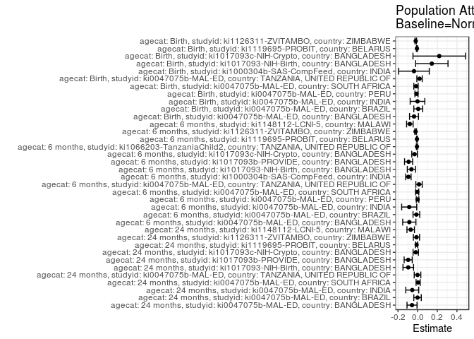

## Results Table

### Parameter: TSM

| agecat | studyid | country | intervention_level | baseline_level | estimate | ci_lower | ci_upper |
| --- | --- | --- | --- | --- | --- | --- | --- |
| Birth | ki0047075b-MAL-ED | BANGLADESH | Normal weight | NA | -0.9356098 | -1.0834640 | -0.7877556 |
| Birth | ki0047075b-MAL-ED | BANGLADESH | Underweight | NA | -1.2421429 | -1.5738055 | -0.9104802 |
| Birth | ki0047075b-MAL-ED | BRAZIL | Normal weight | NA | 0.3770060 | 0.1944840 | 0.5595280 |
| Birth | ki0047075b-MAL-ED | BRAZIL | Underweight | NA | 0.4988889 | -0.3650643 | 1.3628420 |
| Birth | ki0047075b-MAL-ED | INDIA | Normal weight | NA | -1.0683439 | -1.2225022 | -0.9141857 |
| Birth | ki0047075b-MAL-ED | INDIA | Underweight | NA | -1.0763158 | -1.4269951 | -0.7256364 |
| Birth | ki0047075b-MAL-ED | PERU | Normal weight | NA | -0.0544318 | -0.1690482 | 0.0601845 |
| Birth | ki0047075b-MAL-ED | PERU | Underweight | NA | -0.6820000 | -1.1578307 | -0.2061693 |
| Birth | ki0047075b-MAL-ED | SOUTH AFRICA | Normal weight | NA | -0.0178733 | -0.1685692 | 0.1328226 |
| Birth | ki0047075b-MAL-ED | SOUTH AFRICA | Underweight | NA | -0.7740000 | -1.4276053 | -0.1203947 |
| Birth | ki0047075b-MAL-ED | TANZANIA, UNITED REPUBLIC OF | Normal weight | NA | 0.7757798 | 0.5642184 | 0.9873412 |
| Birth | ki0047075b-MAL-ED | TANZANIA, UNITED REPUBLIC OF | Underweight | NA | 1.0942857 | 0.7651658 | 1.4234056 |
| Birth | ki1000304b-SAS-CompFeed | INDIA | Normal weight | NA | -0.1229870 | -0.3619972 | 0.1160232 |
| Birth | ki1000304b-SAS-CompFeed | INDIA | Underweight | NA | -0.2469697 | -0.7015279 | 0.2075886 |
| Birth | ki1017093-NIH-Birth | BANGLADESH | Normal weight | NA | -1.5682609 | -1.9461968 | -1.1903249 |
| Birth | ki1017093-NIH-Birth | BANGLADESH | Underweight | NA | -0.7600000 | -1.2890983 | -0.2309017 |
| Birth | ki1017093c-NIH-Crypto | BANGLADESH | Normal weight | NA | -0.9705882 | -1.5557317 | -0.3854448 |
| Birth | ki1017093c-NIH-Crypto | BANGLADESH | Underweight | NA | -0.1283333 | -0.7259906 | 0.4693239 |
| Birth | ki1119695-PROBIT | BELARUS | Normal weight | NA | -1.1371848 | -1.3474841 | -0.9268855 |
| Birth | ki1119695-PROBIT | BELARUS | Underweight | NA | -1.3192514 | -1.5844560 | -1.0540469 |
| Birth | ki1126311-ZVITAMBO | ZIMBABWE | Normal weight | NA | -0.4703359 | -0.5020572 | -0.4386147 |
| Birth | ki1126311-ZVITAMBO | ZIMBABWE | Underweight | NA | -0.8603728 | -0.9933594 | -0.7273862 |
| 6 months | ki0047075b-MAL-ED | BANGLADESH | Normal weight | NA | -0.0550040 | -0.1835844 | 0.0735764 |
| 6 months | ki0047075b-MAL-ED | BANGLADESH | Underweight | NA | -0.6935937 | -1.1374975 | -0.2496900 |
| 6 months | ki0047075b-MAL-ED | BRAZIL | Normal weight | NA | 0.9775209 | 0.8091090 | 1.1459329 |
| 6 months | ki0047075b-MAL-ED | BRAZIL | Underweight | NA | 0.6764815 | -0.0674862 | 1.4204491 |
| 6 months | ki0047075b-MAL-ED | INDIA | Normal weight | NA | -0.6129391 | -0.7428305 | -0.4830476 |
| 6 months | ki0047075b-MAL-ED | INDIA | Underweight | NA | -1.0246939 | -1.3528167 | -0.6965710 |
| 6 months | ki0047075b-MAL-ED | PERU | Normal weight | NA | 1.0571910 | 0.9326684 | 1.1817136 |
| 6 months | ki0047075b-MAL-ED | PERU | Underweight | NA | 1.0130000 | 0.5008674 | 1.5251326 |
| 6 months | ki0047075b-MAL-ED | SOUTH AFRICA | Normal weight | NA | 0.5333953 | 0.3757046 | 0.6910860 |
| 6 months | ki0047075b-MAL-ED | SOUTH AFRICA | Underweight | NA | 0.3785714 | -0.1478585 | 0.9050014 |
| 6 months | ki0047075b-MAL-ED | TANZANIA, UNITED REPUBLIC OF | Normal weight | NA | 0.5030401 | 0.3694942 | 0.6365859 |
| 6 months | ki0047075b-MAL-ED | TANZANIA, UNITED REPUBLIC OF | Underweight | NA | 0.7502381 | 0.2105756 | 1.2899006 |
| 6 months | ki1000304b-SAS-CompFeed | INDIA | Normal weight | NA | -0.5496743 | -0.6807656 | -0.4185829 |
| 6 months | ki1000304b-SAS-CompFeed | INDIA | Underweight | NA | -0.9301809 | -1.0475858 | -0.8127760 |
| 6 months | ki1017093-NIH-Birth | BANGLADESH | Normal weight | NA | -0.3753518 | -0.4727549 | -0.2779486 |
| 6 months | ki1017093-NIH-Birth | BANGLADESH | Underweight | NA | -0.7416667 | -0.9501078 | -0.5332256 |
| 6 months | ki1017093b-PROVIDE | BANGLADESH | Normal weight | NA | -0.1159618 | -0.2074898 | -0.0244338 |
| 6 months | ki1017093b-PROVIDE | BANGLADESH | Underweight | NA | -0.6453465 | -0.8419203 | -0.4487727 |
| 6 months | ki1017093c-NIH-Crypto | BANGLADESH | Normal weight | NA | 0.0611188 | -0.0205751 | 0.1428127 |
| 6 months | ki1017093c-NIH-Crypto | BANGLADESH | Underweight | NA | -0.2735075 | -0.5552836 | 0.0082687 |
| 6 months | ki1066203-TanzaniaChild2 | TANZANIA, UNITED REPUBLIC OF | Normal weight | NA | 0.0842385 | 0.0298906 | 0.1385864 |
| 6 months | ki1066203-TanzaniaChild2 | TANZANIA, UNITED REPUBLIC OF | Underweight | NA | -0.3194444 | -0.5469897 | -0.0918991 |
| 6 months | ki1119695-PROBIT | BELARUS | Normal weight | NA | 0.5901098 | 0.5324492 | 0.6477705 |
| 6 months | ki1119695-PROBIT | BELARUS | Underweight | NA | 0.4066337 | 0.2758222 | 0.5374452 |
| 6 months | ki1126311-ZVITAMBO | ZIMBABWE | Normal weight | NA | 0.3137533 | 0.2852233 | 0.3422833 |
| 6 months | ki1126311-ZVITAMBO | ZIMBABWE | Underweight | NA | -0.0974100 | -0.2305681 | 0.0357481 |
| 6 months | ki1148112-LCNI-5 | MALAWI | Normal weight | NA | 0.5309696 | 0.4528010 | 0.6091382 |
| 6 months | ki1148112-LCNI-5 | MALAWI | Underweight | NA | 0.0730345 | -0.0870626 | 0.2331315 |
| 24 months | ki0047075b-MAL-ED | BANGLADESH | Normal weight | NA | -0.7635792 | -0.8936854 | -0.6334731 |
| 24 months | ki0047075b-MAL-ED | BANGLADESH | Underweight | NA | -1.1820690 | -1.5022648 | -0.8618731 |
| 24 months | ki0047075b-MAL-ED | BRAZIL | Normal weight | NA | 0.4294444 | 0.2224555 | 0.6364334 |
| 24 months | ki0047075b-MAL-ED | BRAZIL | Underweight | NA | 0.3966667 | -0.6451983 | 1.4385316 |
| 24 months | ki0047075b-MAL-ED | INDIA | Normal weight | NA | -0.8978056 | -1.0217229 | -0.7738882 |
| 24 months | ki0047075b-MAL-ED | INDIA | Underweight | NA | -1.1668478 | -1.4569625 | -0.8767331 |
| 24 months | ki0047075b-MAL-ED | SOUTH AFRICA | Normal weight | NA | 0.4046696 | 0.2835400 | 0.5257992 |
| 24 months | ki0047075b-MAL-ED | SOUTH AFRICA | Underweight | NA | 0.5700000 | -0.1123856 | 1.2523856 |
| 24 months | ki0047075b-MAL-ED | TANZANIA, UNITED REPUBLIC OF | Normal weight | NA | 0.0513793 | -0.0756380 | 0.1783967 |
| 24 months | ki0047075b-MAL-ED | TANZANIA, UNITED REPUBLIC OF | Underweight | NA | 0.0263636 | -0.6148109 | 0.6675382 |
| 24 months | ki1017093-NIH-Birth | BANGLADESH | Normal weight | NA | -0.8161207 | -0.9193416 | -0.7128997 |
| 24 months | ki1017093-NIH-Birth | BANGLADESH | Underweight | NA | -1.3268229 | -1.5771056 | -1.0765402 |
| 24 months | ki1017093b-PROVIDE | BANGLADESH | Normal weight | NA | -0.7901468 | -0.8793237 | -0.7009698 |
| 24 months | ki1017093b-PROVIDE | BANGLADESH | Underweight | NA | -1.3461000 | -1.5428300 | -1.1493700 |
| 24 months | ki1017093c-NIH-Crypto | BANGLADESH | Normal weight | NA | -0.5912739 | -0.6905730 | -0.4919748 |
| 24 months | ki1017093c-NIH-Crypto | BANGLADESH | Underweight | NA | -0.8193023 | -1.1245646 | -0.5140400 |
| 24 months | ki1119695-PROBIT | BELARUS | Normal weight | NA | 0.6972908 | 0.5875138 | 0.8070678 |
| 24 months | ki1119695-PROBIT | BELARUS | Underweight | NA | 0.4089716 | 0.0185287 | 0.7994145 |
| 24 months | ki1126311-ZVITAMBO | ZIMBABWE | Normal weight | NA | -1.1689222 | -1.2830506 | -1.0547937 |
| 24 months | ki1126311-ZVITAMBO | ZIMBABWE | Underweight | NA | -1.3424000 | -1.7745153 | -0.9102847 |
| 24 months | ki1148112-LCNI-5 | MALAWI | Normal weight | NA | 0.0237687 | -0.0655263 | 0.1130638 |
| 24 months | ki1148112-LCNI-5 | MALAWI | Underweight | NA | -0.3982979 | -0.5918111 | -0.2047846 |

### Parameter: E(Y)

| agecat | studyid | country | intervention_level | baseline_level | estimate | ci_lower | ci_upper |
| --- | --- | --- | --- | --- | --- | --- | --- |
| Birth | ki0047075b-MAL-ED | BANGLADESH | NA | NA | -0.9724464 | -1.1091046 | -0.8357881 |
| Birth | ki0047075b-MAL-ED | BRAZIL | NA | NA | 0.3832386 | 0.2044597 | 0.5620175 |
| Birth | ki0047075b-MAL-ED | INDIA | NA | NA | -1.0698974 | -1.2115847 | -0.9282102 |
| Birth | ki0047075b-MAL-ED | PERU | NA | NA | -0.0660967 | -0.1789362 | 0.0467429 |
| Birth | ki0047075b-MAL-ED | SOUTH AFRICA | NA | NA | -0.0346018 | -0.1831486 | 0.1139451 |
| Birth | ki0047075b-MAL-ED | TANZANIA, UNITED REPUBLIC OF | NA | NA | 0.7950000 | 0.5947353 | 0.9952647 |
| Birth | ki1000304b-SAS-CompFeed | INDIA | NA | NA | -0.1601818 | -0.3763991 | 0.0560355 |
| Birth | ki1017093-NIH-Birth | BANGLADESH | NA | NA | -1.4239286 | -1.7688028 | -1.0790544 |
| Birth | ki1017093c-NIH-Crypto | BANGLADESH | NA | NA | -0.7508696 | -1.2358912 | -0.2658480 |
| Birth | ki1119695-PROBIT | BELARUS | NA | NA | -1.1441269 | -1.3547476 | -0.9335062 |
| Birth | ki1126311-ZVITAMBO | ZIMBABWE | NA | NA | -0.4900343 | -0.5209436 | -0.4591251 |
| 6 months | ki0047075b-MAL-ED | BANGLADESH | NA | NA | -0.1397960 | -0.2688682 | -0.0107238 |
| 6 months | ki0047075b-MAL-ED | BRAZIL | NA | NA | 0.9644952 | 0.7999744 | 1.1290160 |
| 6 months | ki0047075b-MAL-ED | INDIA | NA | NA | -0.6987943 | -0.8241325 | -0.5734561 |
| 6 months | ki0047075b-MAL-ED | PERU | NA | NA | 1.0563787 | 0.9342938 | 1.1784635 |
| 6 months | ki0047075b-MAL-ED | SOUTH AFRICA | NA | NA | 0.5290428 | 0.3750394 | 0.6830463 |
| 6 months | ki0047075b-MAL-ED | TANZANIA, UNITED REPUBLIC OF | NA | NA | 0.5170513 | 0.3872178 | 0.6468847 |
| 6 months | ki1000304b-SAS-CompFeed | INDIA | NA | NA | -0.6441020 | -0.7710827 | -0.5171213 |
| 6 months | ki1017093-NIH-Birth | BANGLADESH | NA | NA | -0.4389101 | -0.5279432 | -0.3498771 |
| 6 months | ki1017093b-PROVIDE | BANGLADESH | NA | NA | -0.2079891 | -0.2925599 | -0.1234183 |
| 6 months | ki1017093c-NIH-Crypto | BANGLADESH | NA | NA | 0.0297622 | -0.0491685 | 0.1086930 |
| 6 months | ki1066203-TanzaniaChild2 | TANZANIA, UNITED REPUBLIC OF | NA | NA | 0.0775172 | 0.0241750 | 0.1308595 |
| 6 months | ki1119695-PROBIT | BELARUS | NA | NA | 0.5829956 | 0.5247249 | 0.6412663 |
| 6 months | ki1126311-ZVITAMBO | ZIMBABWE | NA | NA | 0.2928094 | 0.2648167 | 0.3208020 |
| 6 months | ki1148112-LCNI-5 | MALAWI | NA | NA | 0.4515431 | 0.3802415 | 0.5228446 |
| 24 months | ki0047075b-MAL-ED | BANGLADESH | NA | NA | -0.8208255 | -0.9429246 | -0.6987264 |
| 24 months | ki0047075b-MAL-ED | BRAZIL | NA | NA | 0.4282738 | 0.2252365 | 0.6313111 |
| 24 months | ki0047075b-MAL-ED | INDIA | NA | NA | -0.9525664 | -1.0684455 | -0.8366872 |
| 24 months | ki0047075b-MAL-ED | SOUTH AFRICA | NA | NA | 0.4096154 | 0.2902946 | 0.5289362 |
| 24 months | ki0047075b-MAL-ED | TANZANIA, UNITED REPUBLIC OF | NA | NA | 0.0500935 | -0.0748234 | 0.1750103 |
| 24 months | ki1017093-NIH-Birth | BANGLADESH | NA | NA | -0.9115790 | -1.0095022 | -0.8136559 |
| 24 months | ki1017093b-PROVIDE | BANGLADESH | NA | NA | -0.8864991 | -0.9695215 | -0.8034768 |
| 24 months | ki1017093c-NIH-Crypto | BANGLADESH | NA | NA | -0.6103502 | -0.7050157 | -0.5156847 |
| 24 months | ki1119695-PROBIT | BELARUS | NA | NA | 0.6869754 | 0.5725638 | 0.8013869 |
| 24 months | ki1126311-ZVITAMBO | ZIMBABWE | NA | NA | -1.1810028 | -1.2914599 | -1.0705456 |
| 24 months | ki1148112-LCNI-5 | MALAWI | NA | NA | -0.0469519 | -0.1290932 | 0.0351895 |

### Parameter: ATE

| agecat | studyid | country | intervention_level | baseline_level | estimate | ci_lower | ci_upper |
| --- | --- | --- | --- | --- | --- | --- | --- |
| Birth | ki0047075b-MAL-ED | BANGLADESH | Normal weight | Normal weight | 0.0000000 | 0.0000000 | 0.0000000 |
| Birth | ki0047075b-MAL-ED | BANGLADESH | Underweight | Normal weight | -0.3065331 | -0.6696597 | 0.0565935 |
| Birth | ki0047075b-MAL-ED | BRAZIL | Normal weight | Normal weight | 0.0000000 | 0.0000000 | 0.0000000 |
| Birth | ki0047075b-MAL-ED | BRAZIL | Underweight | Normal weight | 0.1218829 | -0.7611399 | 1.0049057 |
| Birth | ki0047075b-MAL-ED | INDIA | Normal weight | Normal weight | 0.0000000 | 0.0000000 | 0.0000000 |
| Birth | ki0047075b-MAL-ED | INDIA | Underweight | Normal weight | -0.0079718 | -0.3910394 | 0.3750958 |
| Birth | ki0047075b-MAL-ED | PERU | Normal weight | Normal weight | 0.0000000 | 0.0000000 | 0.0000000 |
| Birth | ki0047075b-MAL-ED | PERU | Underweight | Normal weight | -0.6275682 | -1.1170084 | -0.1381280 |
| Birth | ki0047075b-MAL-ED | SOUTH AFRICA | Normal weight | Normal weight | 0.0000000 | 0.0000000 | 0.0000000 |
| Birth | ki0047075b-MAL-ED | SOUTH AFRICA | Underweight | Normal weight | -0.7561267 | -1.4268793 | -0.0853741 |
| Birth | ki0047075b-MAL-ED | TANZANIA, UNITED REPUBLIC OF | Normal weight | Normal weight | 0.0000000 | 0.0000000 | 0.0000000 |
| Birth | ki0047075b-MAL-ED | TANZANIA, UNITED REPUBLIC OF | Underweight | Normal weight | 0.3185059 | -0.0727461 | 0.7097579 |
| Birth | ki1000304b-SAS-CompFeed | INDIA | Normal weight | Normal weight | 0.0000000 | 0.0000000 | 0.0000000 |
| Birth | ki1000304b-SAS-CompFeed | INDIA | Underweight | Normal weight | -0.1239827 | -0.6433028 | 0.3953374 |
| Birth | ki1017093-NIH-Birth | BANGLADESH | Normal weight | Normal weight | 0.0000000 | 0.0000000 | 0.0000000 |
| Birth | ki1017093-NIH-Birth | BANGLADESH | Underweight | Normal weight | 0.8082609 | 0.1580450 | 1.4584767 |
| Birth | ki1017093c-NIH-Crypto | BANGLADESH | Normal weight | Normal weight | 0.0000000 | 0.0000000 | 0.0000000 |
| Birth | ki1017093c-NIH-Crypto | BANGLADESH | Underweight | Normal weight | 0.8422549 | 0.0058417 | 1.6786681 |
| Birth | ki1119695-PROBIT | BELARUS | Normal weight | Normal weight | 0.0000000 | 0.0000000 | 0.0000000 |
| Birth | ki1119695-PROBIT | BELARUS | Underweight | Normal weight | -0.1820666 | -0.3289838 | -0.0351494 |
| Birth | ki1126311-ZVITAMBO | ZIMBABWE | Normal weight | Normal weight | 0.0000000 | 0.0000000 | 0.0000000 |
| Birth | ki1126311-ZVITAMBO | ZIMBABWE | Underweight | Normal weight | -0.3900369 | -0.5267544 | -0.2533194 |
| 6 months | ki0047075b-MAL-ED | BANGLADESH | Normal weight | Normal weight | 0.0000000 | 0.0000000 | 0.0000000 |
| 6 months | ki0047075b-MAL-ED | BANGLADESH | Underweight | Normal weight | -0.6385898 | -1.1007407 | -0.1764389 |
| 6 months | ki0047075b-MAL-ED | BRAZIL | Normal weight | Normal weight | 0.0000000 | 0.0000000 | 0.0000000 |
| 6 months | ki0047075b-MAL-ED | BRAZIL | Underweight | Normal weight | -0.3010395 | -1.0638307 | 0.4617517 |
| 6 months | ki0047075b-MAL-ED | INDIA | Normal weight | Normal weight | 0.0000000 | 0.0000000 | 0.0000000 |
| 6 months | ki0047075b-MAL-ED | INDIA | Underweight | Normal weight | -0.4117548 | -0.7646520 | -0.0588577 |
| 6 months | ki0047075b-MAL-ED | PERU | Normal weight | Normal weight | 0.0000000 | 0.0000000 | 0.0000000 |
| 6 months | ki0047075b-MAL-ED | PERU | Underweight | Normal weight | -0.0441910 | -0.5712448 | 0.4828628 |
| 6 months | ki0047075b-MAL-ED | SOUTH AFRICA | Normal weight | Normal weight | 0.0000000 | 0.0000000 | 0.0000000 |
| 6 months | ki0047075b-MAL-ED | SOUTH AFRICA | Underweight | Normal weight | -0.1548239 | -0.7043645 | 0.3947167 |
| 6 months | ki0047075b-MAL-ED | TANZANIA, UNITED REPUBLIC OF | Normal weight | Normal weight | 0.0000000 | 0.0000000 | 0.0000000 |
| 6 months | ki0047075b-MAL-ED | TANZANIA, UNITED REPUBLIC OF | Underweight | Normal weight | 0.2471980 | -0.3087427 | 0.8031387 |
| 6 months | ki1000304b-SAS-CompFeed | INDIA | Normal weight | Normal weight | 0.0000000 | 0.0000000 | 0.0000000 |
| 6 months | ki1000304b-SAS-CompFeed | INDIA | Underweight | Normal weight | -0.3805067 | -0.4590215 | -0.3019918 |
| 6 months | ki1017093-NIH-Birth | BANGLADESH | Normal weight | Normal weight | 0.0000000 | 0.0000000 | 0.0000000 |
| 6 months | ki1017093-NIH-Birth | BANGLADESH | Underweight | Normal weight | -0.3663149 | -0.5963911 | -0.1362387 |
| 6 months | ki1017093b-PROVIDE | BANGLADESH | Normal weight | Normal weight | 0.0000000 | 0.0000000 | 0.0000000 |
| 6 months | ki1017093b-PROVIDE | BANGLADESH | Underweight | Normal weight | -0.5293847 | -0.7462225 | -0.3125469 |
| 6 months | ki1017093c-NIH-Crypto | BANGLADESH | Normal weight | Normal weight | 0.0000000 | 0.0000000 | 0.0000000 |
| 6 months | ki1017093c-NIH-Crypto | BANGLADESH | Underweight | Normal weight | -0.3346263 | -0.6280061 | -0.0412465 |
| 6 months | ki1066203-TanzaniaChild2 | TANZANIA, UNITED REPUBLIC OF | Normal weight | Normal weight | 0.0000000 | 0.0000000 | 0.0000000 |
| 6 months | ki1066203-TanzaniaChild2 | TANZANIA, UNITED REPUBLIC OF | Underweight | Normal weight | -0.4036829 | -0.6376286 | -0.1697373 |
| 6 months | ki1119695-PROBIT | BELARUS | Normal weight | Normal weight | 0.0000000 | 0.0000000 | 0.0000000 |
| 6 months | ki1119695-PROBIT | BELARUS | Underweight | Normal weight | -0.1834762 | -0.2974540 | -0.0694983 |
| 6 months | ki1126311-ZVITAMBO | ZIMBABWE | Normal weight | Normal weight | 0.0000000 | 0.0000000 | 0.0000000 |
| 6 months | ki1126311-ZVITAMBO | ZIMBABWE | Underweight | Normal weight | -0.4111633 | -0.5473435 | -0.2749831 |
| 6 months | ki1148112-LCNI-5 | MALAWI | Normal weight | Normal weight | 0.0000000 | 0.0000000 | 0.0000000 |
| 6 months | ki1148112-LCNI-5 | MALAWI | Underweight | Normal weight | -0.4579351 | -0.6360963 | -0.2797740 |
| 24 months | ki0047075b-MAL-ED | BANGLADESH | Normal weight | Normal weight | 0.0000000 | 0.0000000 | 0.0000000 |
| 24 months | ki0047075b-MAL-ED | BANGLADESH | Underweight | Normal weight | -0.4184897 | -0.7641095 | -0.0728700 |
| 24 months | ki0047075b-MAL-ED | BRAZIL | Normal weight | Normal weight | 0.0000000 | 0.0000000 | 0.0000000 |
| 24 months | ki0047075b-MAL-ED | BRAZIL | Underweight | Normal weight | -0.0327778 | -1.0950051 | 1.0294496 |
| 24 months | ki0047075b-MAL-ED | INDIA | Normal weight | Normal weight | 0.0000000 | 0.0000000 | 0.0000000 |
| 24 months | ki0047075b-MAL-ED | INDIA | Underweight | Normal weight | -0.2690423 | -0.5845134 | 0.0464289 |
| 24 months | ki0047075b-MAL-ED | SOUTH AFRICA | Normal weight | Normal weight | 0.0000000 | 0.0000000 | 0.0000000 |
| 24 months | ki0047075b-MAL-ED | SOUTH AFRICA | Underweight | Normal weight | 0.1653304 | -0.5277226 | 0.8583834 |
| 24 months | ki0047075b-MAL-ED | TANZANIA, UNITED REPUBLIC OF | Normal weight | Normal weight | 0.0000000 | 0.0000000 | 0.0000000 |
| 24 months | ki0047075b-MAL-ED | TANZANIA, UNITED REPUBLIC OF | Underweight | Normal weight | -0.0250157 | -0.6786503 | 0.6286189 |
| 24 months | ki1017093-NIH-Birth | BANGLADESH | Normal weight | Normal weight | 0.0000000 | 0.0000000 | 0.0000000 |
| 24 months | ki1017093-NIH-Birth | BANGLADESH | Underweight | Normal weight | -0.5107022 | -0.7814346 | -0.2399699 |
| 24 months | ki1017093b-PROVIDE | BANGLADESH | Normal weight | Normal weight | 0.0000000 | 0.0000000 | 0.0000000 |
| 24 months | ki1017093b-PROVIDE | BANGLADESH | Underweight | Normal weight | -0.5559532 | -0.7719514 | -0.3399550 |
| 24 months | ki1017093c-NIH-Crypto | BANGLADESH | Normal weight | Normal weight | 0.0000000 | 0.0000000 | 0.0000000 |
| 24 months | ki1017093c-NIH-Crypto | BANGLADESH | Underweight | Normal weight | -0.2280284 | -0.5490353 | 0.0929784 |
| 24 months | ki1119695-PROBIT | BELARUS | Normal weight | Normal weight | 0.0000000 | 0.0000000 | 0.0000000 |
| 24 months | ki1119695-PROBIT | BELARUS | Underweight | Normal weight | -0.2883192 | -0.6305563 | 0.0539180 |
| 24 months | ki1126311-ZVITAMBO | ZIMBABWE | Normal weight | Normal weight | 0.0000000 | 0.0000000 | 0.0000000 |
| 24 months | ki1126311-ZVITAMBO | ZIMBABWE | Underweight | Normal weight | -0.1734778 | -0.6204107 | 0.2734550 |
| 24 months | ki1148112-LCNI-5 | MALAWI | Normal weight | Normal weight | 0.0000000 | 0.0000000 | 0.0000000 |
| 24 months | ki1148112-LCNI-5 | MALAWI | Underweight | Normal weight | -0.4220666 | -0.6351886 | -0.2089446 |

### Parameter: PAR

| agecat | studyid | country | intervention_level | baseline_level | estimate | ci_lower | ci_upper |
| --- | --- | --- | --- | --- | --- | --- | --- |
| Birth | ki0047075b-MAL-ED | BANGLADESH | Normal weight | NA | -0.0368366 | -0.0823199 | 0.0086467 |
| Birth | ki0047075b-MAL-ED | BRAZIL | Normal weight | NA | 0.0062326 | -0.0390968 | 0.0515621 |
| Birth | ki0047075b-MAL-ED | INDIA | Normal weight | NA | -0.0015535 | -0.0762039 | 0.0730969 |
| Birth | ki0047075b-MAL-ED | PERU | Normal weight | NA | -0.0116648 | -0.0275614 | 0.0042317 |
| Birth | ki0047075b-MAL-ED | SOUTH AFRICA | Normal weight | NA | -0.0167285 | -0.0389179 | 0.0054610 |
| Birth | ki0047075b-MAL-ED | TANZANIA, UNITED REPUBLIC OF | Normal weight | NA | 0.0192202 | -0.0081584 | 0.0465987 |
| Birth | ki1000304b-SAS-CompFeed | INDIA | Normal weight | NA | -0.0371948 | -0.1926695 | 0.1182799 |
| Birth | ki1017093-NIH-Birth | BANGLADESH | Normal weight | NA | 0.1443323 | -0.0203351 | 0.3089996 |
| Birth | ki1017093c-NIH-Crypto | BANGLADESH | Normal weight | NA | 0.2197187 | -0.0476628 | 0.4871001 |
| Birth | ki1119695-PROBIT | BELARUS | Normal weight | NA | -0.0069421 | -0.0125495 | -0.0013346 |
| Birth | ki1126311-ZVITAMBO | ZIMBABWE | Normal weight | NA | -0.0196984 | -0.0268244 | -0.0125724 |
| 6 months | ki0047075b-MAL-ED | BANGLADESH | Normal weight | NA | -0.0847920 | -0.1520021 | -0.0175819 |
| 6 months | ki0047075b-MAL-ED | BRAZIL | Normal weight | NA | -0.0130257 | -0.0470695 | 0.0210180 |
| 6 months | ki0047075b-MAL-ED | INDIA | Normal weight | NA | -0.0858553 | -0.1624958 | -0.0092148 |
| 6 months | ki0047075b-MAL-ED | PERU | Normal weight | NA | -0.0008123 | -0.0140076 | 0.0123830 |
| 6 months | ki0047075b-MAL-ED | SOUTH AFRICA | Normal weight | NA | -0.0043525 | -0.0201263 | 0.0114214 |
| 6 months | ki0047075b-MAL-ED | TANZANIA, UNITED REPUBLIC OF | Normal weight | NA | 0.0140112 | -0.0182990 | 0.0463215 |
| 6 months | ki1000304b-SAS-CompFeed | INDIA | Normal weight | NA | -0.0944278 | -0.1220383 | -0.0668172 |
| 6 months | ki1017093-NIH-Birth | BANGLADESH | Normal weight | NA | -0.0635584 | -0.1051729 | -0.0219438 |
| 6 months | ki1017093b-PROVIDE | BANGLADESH | Normal weight | NA | -0.0920273 | -0.1331061 | -0.0509485 |
| 6 months | ki1017093c-NIH-Crypto | BANGLADESH | Normal weight | NA | -0.0313566 | -0.0597634 | -0.0029498 |
| 6 months | ki1066203-TanzaniaChild2 | TANZANIA, UNITED REPUBLIC OF | Normal weight | NA | -0.0067213 | -0.0129966 | -0.0004459 |
| 6 months | ki1119695-PROBIT | BELARUS | Normal weight | NA | -0.0071142 | -0.0114363 | -0.0027922 |
| 6 months | ki1126311-ZVITAMBO | ZIMBABWE | Normal weight | NA | -0.0209440 | -0.0281931 | -0.0136949 |
| 6 months | ki1148112-LCNI-5 | MALAWI | Normal weight | NA | -0.0794265 | -0.1124900 | -0.0463631 |
| 24 months | ki0047075b-MAL-ED | BANGLADESH | Normal weight | NA | -0.0572462 | -0.1083512 | -0.0061412 |
| 24 months | ki0047075b-MAL-ED | BRAZIL | Normal weight | NA | -0.0011706 | -0.0391185 | 0.0367773 |
| 24 months | ki0047075b-MAL-ED | INDIA | Normal weight | NA | -0.0547608 | -0.1205133 | 0.0109916 |
| 24 months | ki0047075b-MAL-ED | SOUTH AFRICA | Normal weight | NA | 0.0049458 | -0.0160996 | 0.0259912 |
| 24 months | ki0047075b-MAL-ED | TANZANIA, UNITED REPUBLIC OF | Normal weight | NA | -0.0012859 | -0.0348921 | 0.0323204 |
| 24 months | ki1017093-NIH-Birth | BANGLADESH | Normal weight | NA | -0.0954584 | -0.1494712 | -0.0414455 |
| 24 months | ki1017093b-PROVIDE | BANGLADESH | Normal weight | NA | -0.0963524 | -0.1375433 | -0.0551615 |
| 24 months | ki1017093c-NIH-Crypto | BANGLADESH | Normal weight | NA | -0.0190763 | -0.0464811 | 0.0083285 |
| 24 months | ki1119695-PROBIT | BELARUS | Normal weight | NA | -0.0103154 | -0.0216044 | 0.0009736 |
| 24 months | ki1126311-ZVITAMBO | ZIMBABWE | Normal weight | NA | -0.0120806 | -0.0435384 | 0.0193771 |
| 24 months | ki1148112-LCNI-5 | MALAWI | Normal weight | NA | -0.0707206 | -0.1087426 | -0.0326986 |